# Lab-4

Tejaswini Sengaonkar

2023-08-21

### STATS 769 Lab 04

```r
library(arrow)
library(biglm)
library(iotools)
```

#### Explore

1. First, we want to understand the trip_miles and trip_time variables. Check both variables for plausibility, plot their distributions (transformations may be advisable) and comment on the results.

```r
data <- arrow::read_parquet("/course/data/nyctaxi/parquet/fhvhv_tripdata_2023-01.parquet")
head(data)
```

```
##   hvfhs_license_num dispatching_base_num originating_base_num
## 1            HV0003               B03404               B03404
## 2            HV0003               B03404               B03404
## 3            HV0003               B03404               B03404
## 4            HV0003               B03404               B03404
## 5            HV0003               B03404               B03404
## 6            HV0005               B03406                 <NA>
##      request_datetime   on_scene_datetime     pickup_datetime
## 1 2023-01-01 13:18:06 2023-01-01 13:19:24 2023-01-01 13:19:38
## 2 2023-01-01 13:48:42 2023-01-01 13:56:20 2023-01-01 13:58:39
## 3 2023-01-01 13:15:35 2023-01-01 13:20:14 2023-01-01 13:20:27
## 4 2023-01-01 13:35:24 2023-01-01 13:39:30 2023-01-01 13:41:05
## 5 2023-01-01 13:43:15 2023-01-01 13:51:10 2023-01-01 13:52:47
## 6 2023-01-01 13:21:34                <NA> 2023-01-01 13:29:05
##      dropoff_datetime PULocationID DOLocationID trip_miles trip_time
```

[output cut: 27 more lines]

```r
summary(data$trip_miles)
```

```
##    Min. 1st Qu.  Median    Mean 3rd Qu.    Max.
##   0.000   1.550   2.897   4.870   6.015 407.563
```

```r
summary(data$trip_time)
```

```
##    Min. 1st Qu.  Median    Mean 3rd Qu.    Max.
##       0     575     906    1095    1404   35359
```

```r
na_counts <- colSums(is.na(data))
na_counts
```

```
##    hvfhs_license_num dispatching_base_num originating_base_num
##                    0                    0              4891992
##     request_datetime    on_scene_datetime      pickup_datetime
##                    0              4891992                    0
##     dropoff_datetime         PULocationID         DOLocationID
##                    0                    0                    0
##           trip_miles            trip_time  base_passenger_fare
##                    0                    0                    0
##                tolls                  bcf            sales_tax
##                    0                    0                    0
## congestion_surcharge          airport_fee                 tips
##                    0                    0                    0
##           driver_pay  shared_request_flag    shared_match_flag
##                    0                    0                    0
##   access_a_ride_flag     wav_request_flag       wav_match_flag
##                    0                    0                    0
```

```r
non_negative_columns <- c("trip_miles", "trip_time", "driver_pay", "base_passenger_fare")
non_negative_check <- colSums(data[non_negative_columns] >= 0)
non_negative_check
```

```
##          trip_miles           trip_time          driver_pay base_passenger_fare
##            18479031            18479031            18478716            18465591
```

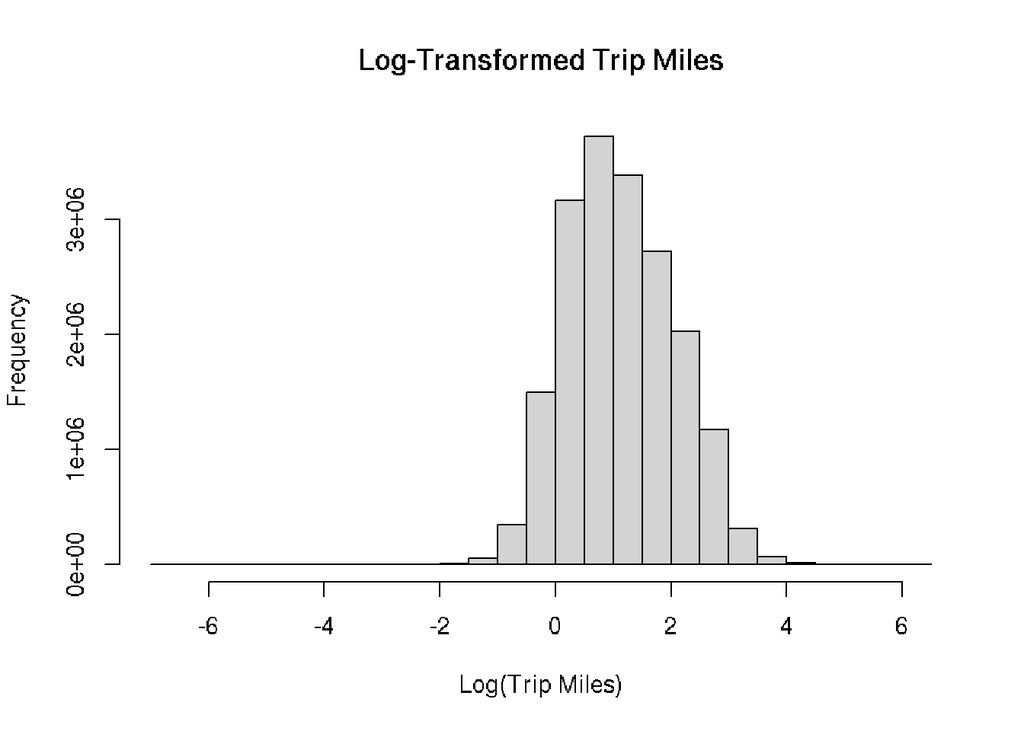

```r
data$trip_miles_log <- log(data$trip_miles)
data$trip_time_log <- log(data$trip_time)
hist(data$trip_miles_log, main = "Log-Transformed Trip Miles", xlab = "Log(Trip Miles)")
```

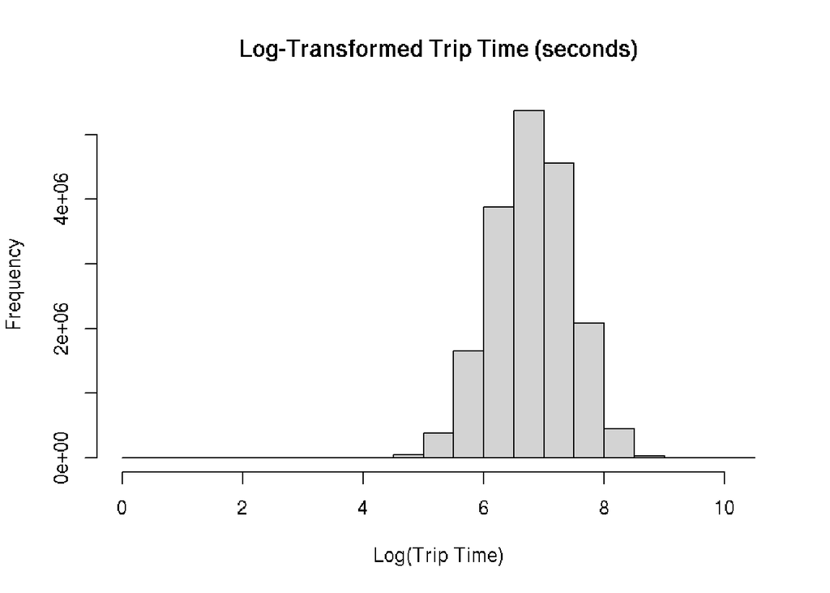

```r
hist(data$trip_time_log, main = "Log-Transformed Trip Time (seconds)", xlab = "Log(Trip Time)")
```

2. Similarly, check the variables driver_pay and base_passenger_fare for plausibility and their distributions. Comment on the results.

```r
data$driver_pay_log <- log(data$driver_pay)
data$base_passenger_fare_log <- log(data$base_passenger_fare)
```

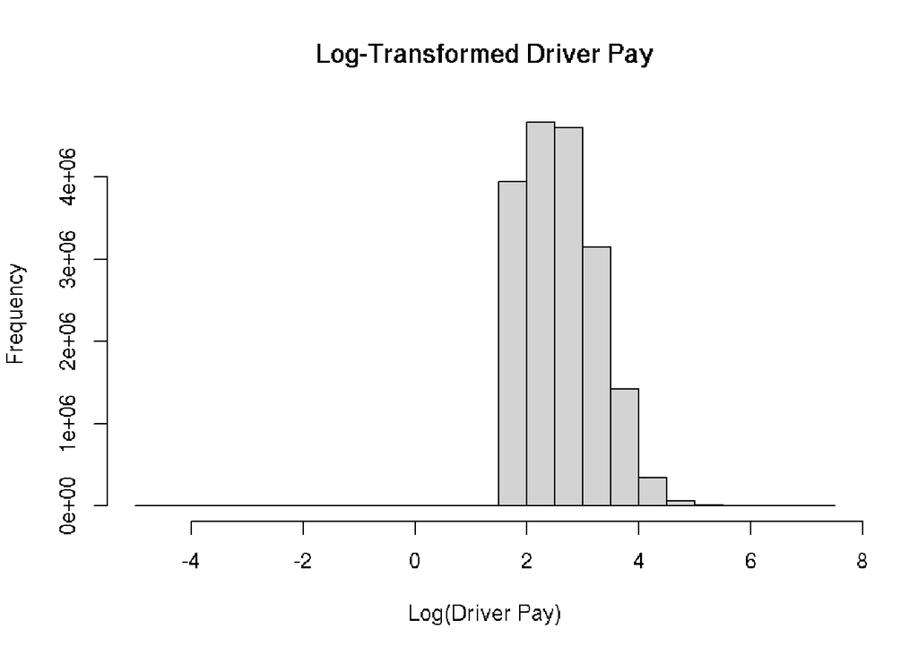

```r
hist(data$driver_pay_log, main = "Log-Transformed Driver Pay", xlab = "Log(Driver Pay)")
```

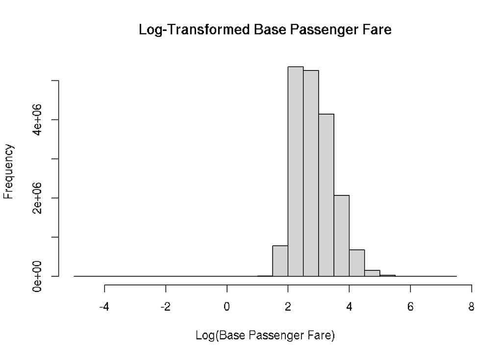

```r
hist(data$base_passenger_fare_log, main = "Log-Transformed Base Passenger Fare", xlab = "Log(Base Passenger Fare)")
```

From the plots we can say the distribution is right-skewed.

#### Model

3. We want to model the relationship between the trip time, trip length and driver pay. In the following make sure you remove any implausible records from further analysis as identified in the previous two questions. Use a linear model with the trip time in hours and trip length in miles as predictors to model the driver pay. Interpret the resulting coefficients and their meaning.

```r
data_filtered <- data[data$trip_miles > 0 &
                       data$trip_time > 0 &
                       data$driver_pay > 0 &
                       data$base_passenger_fare > 0, ]

data_filtered$trip_time_hours <- data_filtered$trip_time / 3600
model_one <- lm(driver_pay ~ trip_time_hours + trip_miles, data = data_filtered)
summary(model_one)
```

```
##
## Call:
## lm(formula = driver_pay ~ trip_time_hours + trip_miles, data = data_filtered)
##
## Residuals:
##     Min      1Q  Median      3Q     Max
## -385.66   -1.46   -1.02    0.31  886.11
##
## Coefficients:
##                  Estimate Std. Error t value Pr(>|t|)
## (Intercept)     1.167e+00  1.831e-03   637.6   <2e-16 ***
## trip_time_hours 2.956e+01  8.026e-03  3683.5   <2e-16 ***
## trip_miles      1.426e+00  2.924e-04  4874.6   <2e-16 ***
## ---
## Signif. codes:  0 '***' 0.001 '**' 0.01 '*' 0.05 '.' 0.1 ' ' 1
##
## Residual standard error: 4.2 on 18172992 degrees of freedom
## Multiple R-squared:  0.9116, Adjusted R-squared:  0.9116
## F-statistic: 9.365e+07 on 2 and 18172992 DF,  p-value: < 2.2e-16
```

4. Compute the root mean squared error (RMSE) of your model fit. Do you think it is a good fit?

```r
RMSE <- function(obs, pred) sqrt(mean((obs - pred)^2))
actual_values <- data_filtered$driver_pay
RMSE(actual_values, predict(model_one, data = data_filtered))
```

```
## [1] 4.200475
```

Considering the RMSE value, we can say that the model is not a good fit.

5.Plot the model residuals vs the response variable. Comment on the resulting plot and propose a theory explaining the visible artifacts.

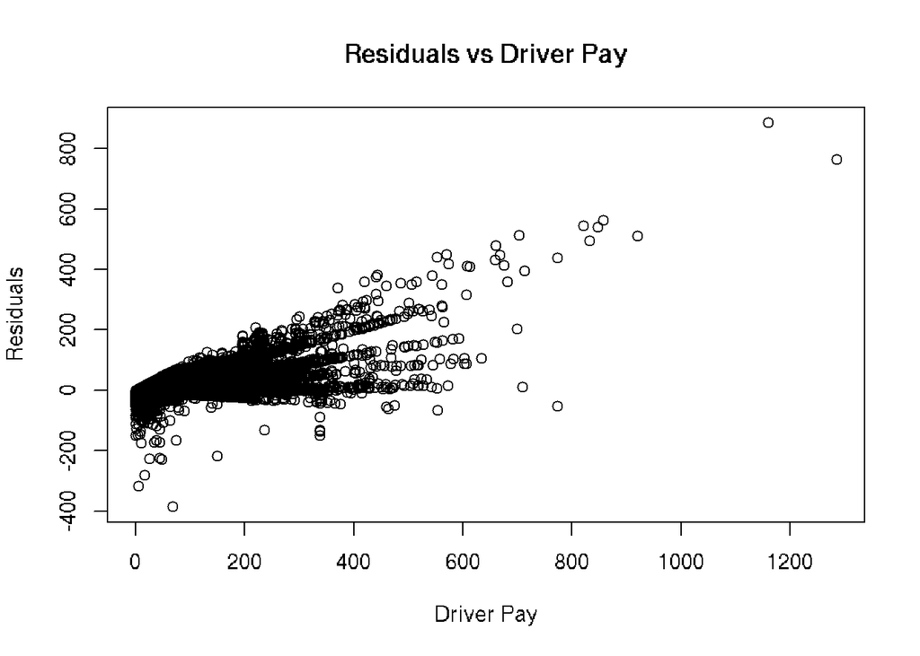

```r
plot(data_filtered$driver_pay, resid(model_one),
       xlab = "Driver Pay", ylab = "Residuals",
       main = "Residuals vs Driver Pay")
```

There is a spread of residuals that tends to increase as the response variable increases. This creates a widening or narrowing funnel-like pattern. We also observe Heteroscedasticity, that means the variability of residuals differs across different levels of the response variable.

#### Large data

6.We want to fit a linear model with the formula driver_pay ~ trip_miles + hvfhs_license_num * trip_time_h to the entire dataset. We want to limit the memory usage, so you have to use the biglm and iotools packages. Use chunk.reader(xzfile(…, “rb”)) to decompress and read the above file chunkwise, extract a data frame with the columns hvfhs_license_num, trip_miles, trip_time, driver_pay and base_passenger_fare using dstrsplit() from each chunk, filter our records with implausible values, convert trip time to hours as the trip_time_h column and use the biglm package to fit the linear model. After each processed chunk, print the model and its coefficients.

```r
chunk_reader <- chunk.reader(xzfile("/course/data/nyctaxi/csv/fhvhv_tripdata_2023.csv.xz", "rb"))


while (length(chunk <- read.chunk(chunk_reader))) {
   d <- dstrsplit(chunk, list(
     hvfhs_license_num = "",
     NA,NA,NA,NA,NA,NA,NA,NA,
     trip_miles = 1,
     trip_time = 1,
     base_passenger_fare = 1,
     NA,NA,NA,NA,NA,NA,
     driver_pay = 1), sep = ",", strict = FALSE)

   d_filtered <- d[d$trip_miles > 0 &
                   d$trip_time > 0 &
                   d$driver_pay > 0 &
                   d$base_passenger_fare > 0, ]

   d_filtered$trip_time_h <- d_filtered$trip_time / 3600

   bglm_model <- biglm(driver_pay ~ trip_miles + hvfhs_license_num * trip_time_h, data = d_filtered)

   print(summary(bglm_model))
   cat("\n")
}
```

**Output -**

**First Model -** Large data regression model: biglm(driver_pay ~ trip_miles + hvfhs_license_num * trip_time_h, data = d_filtered) Sample size = 217526 Coef (95% CI) SE p (Intercept) 0.9445 0.9106 0.9784 0.0170 0 trip_miles 1.4663 1.4610 1.4716 0.0027 0 hvfhs_license_numHV0005 -0.2674 -0.3299 -0.2050 0.0312 0 trip_time_h 29.2949 29.1555 29.4342 0.0697 0 hvfhs_license_numHV0005:trip_time_h -1.5012 -1.6619 -1.3406 0.0803 0

**Final Model -** Large data regression model: biglm(driver_pay ~ trip_miles + hvfhs_license_num * trip_time_h, data = d_filtered) Sample size = 143015 Coef (95% CI) SE p (Intercept) 1.9024 1.8408 1.9641 0.0308 0 trip_miles 1.8454 1.8354 1.8553 0.0050 0 hvfhs_license_numHV0005 -1.1987 -1.3095 -1.0880 0.0554 0 trip_time_h 28.9844 28.7071 29.2617 0.1387 0 hvfhs_license_numHV0005:trip_time_h -1.8990 -2.1890 -1.6090 0.1450 0

Overall, Longer trip distances and durations tend to increase driver pay, while having license number HV0005 and longer trip durations for that license number tend to decrease driver pay. These coefficients provide insights into the factors that contribute to variations in driver pay in the context of high-volume for-hire services.

7.Is it possible to compute the final RMSE as part of the model fitting process (i.e. as part of the code you wrote above)? Explain why yes or no

No, it’s not possible to compute the final Root Mean Squared Error (RMSE) as part of the model fitting process when using chunk wise processing. The reason is that chunk wise processing involves processing the data in smaller chunks or segments rather than the entire data set at once. Since the RMSE is a metric that requires comparing the model’s predictions with the actual target values, you need all the predictions and actual values to compute it accurately.

In chunk wise processing, you are fitting the model to subsets of the data (chunks) sequentially. As each chunk is processed, the model parameters (coefficients) are updated based on that chunk’s data. However, you cannot compute the final RMSE until you have processed all the chunks and collected all the predictions and actual values from the entire dataset. This is because RMSE involves calculating the squared differences between predicted and actual values, and then taking the square root of the average of those squared differences.

To compute the final RMSE, you would need to store the predictions and actual values for each chunk, and then once all the chunks are processed, you can calculate the RMSE using the aggregated predictions and actual values. This requires additional memory and bookkeeping to keep track of the predictions and actual values for each chunk.

#### Summary

8. Write a short summary of your findings

The objective of this lab was to explore large data analysis using the NYC HVFHV dataset. The lab covered various aspects of data exploration, transformation, modeling and chunk wise processing.

Data Exploration -First we checked the plausibility of variables like trip_miles and trip_time. Distributions of these variables were plotted, and it was observed that they had right-skewed distributions. Log-transformations were applied to these variables to reduce skewness. Similar analysis was performed for driver_pay and base_passenger_fare. Log-transformations were applied to these variables as well, and their distributions were visualized.

Modeling - A linear model was built to understand the relationship between trip_time, trip_miles, and driver_pay. Implausible records were removed, and the model was fitted using the transformed trip_time in hours and trip_miles. Coefficients were interpreted, indicating that longer trips in terms of time and distance were associated with higher driver pay. The residual standard error was used to assess the model’s fit.The Root Mean Squared Error (RMSE) was calculated to evaluate the model’s fit. A high RMSE suggested that the model might not be a good fit for the data.Residuals were plotted against the response variable (driver_pay). Heteroscedasticity was observed, indicating that the variability of residuals differed across different levels of the response variable.